# Storm Data Analysis

Nancy

2024-09-09

# Impact of Severe Weather Events on Public Health and Economic Consequences

## Introduction

Severe weather events such as storms can result in significant public health and economic challenges for communities. Fatalities, injuries, and property damage are common outcomes of such events, and minimizing their impact is a priority for disaster preparedness and response. This report analyzes data from the U.S. National Oceanic and Atmospheric Administration’s (NOAA) storm database to understand the types of weather events that most affect population health and have the greatest economic consequences.

## Data

The NOAA storm database includes data on major storms and weather events across the United States from 1950 through November 2011. It records event characteristics such as location, fatalities, injuries, and property damage. The analysis focuses on event types (EVTYPE) and their related public health and economic impacts.

## Results

1. Population Health Impact The analysis of fatalities and injuries shows that tornadoes have the most severe impact on public health, causing the highest number of both fatalities and injuries.
2. Economic Impact In terms of economic consequences, floods and hurricanes/typhoons were found to cause the greatest damage, with significant costs in both property and crop damage.

### Data Download and Loading

```
## [1] "Data: "
```

```
## [1] 985
```

```
## Classes 'data.table' and 'data.frame':   902297 obs. of  37 variables:
##  $ STATE__   : chr  "1.00" "1.00" "1.00" "1.00" ...
##  $ BGN_DATE  : chr  "4/18/1950 0:00:00" "4/18/1950 0:00:00" "2/20/1951 0:00:00" "6/8/1951 0:00:00" ...
##  $ BGN_TIME  : chr  "0130" "0145" "1600" "0900" ...
##  $ TIME_ZONE : chr  "CST" "CST" "CST" "CST" ...
##  $ COUNTY    : num  97 3 57 89 43 77 9 123 125 57 ...
##  $ COUNTYNAME: chr  "MOBILE" "BALDWIN" "FAYETTE" "MADISON" ...
##  $ STATE     : chr  "AL" "AL" "AL" "AL" ...
##  $ EVTYPE    : chr  "TORNADO" "TORNADO" "TORNADO" "TORNADO" ...
##  $ BGN_RANGE : num  0 0 0 0 0 0 0 0 0 0 ...
##  $ BGN_AZI   : chr  "" "" "" "" ...
##  $ BGN_LOCATI: chr  "" "" "" "" ...
##  $ END_DATE  : chr  "" "" "" "" ...
##  $ END_TIME  : chr  "" "" "" "" ...
##  $ COUNTY_END: num  0 0 0 0 0 0 0 0 0 0 ...
```

[output cut: 24 more lines]

Table: Storm Data

### Data Subsetting

```
## Classes 'data.table' and 'data.frame':   902297 obs. of  7 variables:
##  $ evtype    : chr  "TORNADO" "TORNADO" "TORNADO" "TORNADO" ...
##  $ fatalities: num  0 0 0 0 0 0 0 0 1 0 ...
##  $ injuries  : num  15 0 2 2 2 6 1 0 14 0 ...
##  $ propdmg   : num  25 2.5 25 2.5 2.5 2.5 2.5 2.5 25 25 ...
##  $ propdmgexp: chr  "K" "K" "K" "K" ...
##  $ cropdmg   : num  0 0 0 0 0 0 0 0 0 0 ...
##  $ cropdmgexp: chr  "" "" "" "" ...
##  - attr(*, ".internal.selfref")=<externalptr>
```

Table: Data subsetted

### Function to convert exponent values

```r
convert_exponent <- function(exp) {
  if (exp == "H" || exp == "h") return(1e2)
  if (exp == "K" || exp == "k") return(1e3)
  if (exp == "M" || exp == "m") return(1e6)
  if (exp == "B" || exp == "b") return(1e9)
  return(1)
}
```

### Population Health Analysis (Fatalities & Injuries)

```
## tibble [20 × 3] (S3: tbl_df/tbl/data.frame)
##  $ evtype: chr [1:20] "TORNADO" "TORNADO" "EXCESSIVE HEAT" "EXCESSIVE HEAT" ...
##  $ type  : chr [1:20] "fatalities" "injuries" "fatalities" "injuries" ...
##  $ value : num [1:20] 5633 91346 1903 6525 978 ...
```

Table: Population Health Analysis Data

### Economic Consequences Analysis (Property & Crop Damage)

```
## tibble [20 × 3] (S3: tbl_df/tbl/data.frame)
##  $ evtype: chr [1:20] "FLOOD" "FLOOD" "HURRICANE/TYPHOON" "HURRICANE/TYPHOON" ...
##  $ type  : chr [1:20] "property_damage" "crop_damage" "property_damage" "crop_damage" ...
##  $ value : num [1:20] 1.45e+11 5.66e+09 6.93e+10 2.61e+09 5.69e+10 ...
```

[figure not shown]

### Visualization: Economic Damage (Property & Crop Damage)

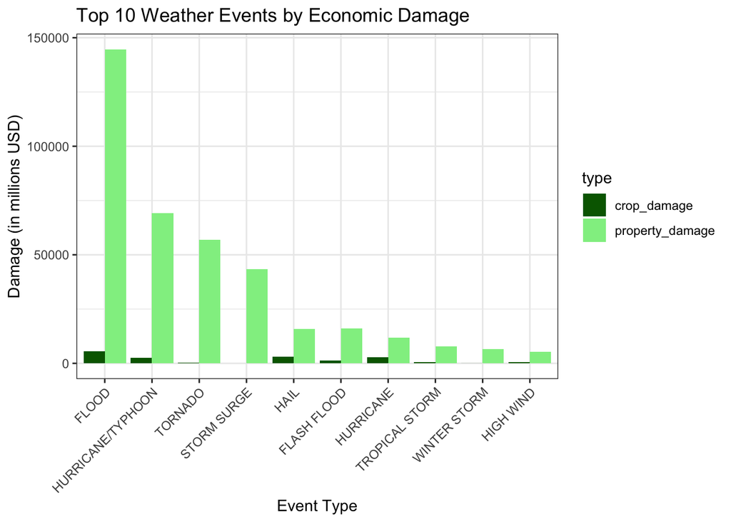

## Conclusion:

This analysis highlights the importance of focusing on tornadoes to mitigate risks to population health. Improved infrastructure and early warning systems could help reduce injuries and fatalities. In terms of economic damage, the most costly events—floods and hurricanes/typhoons—warrant investment in innovative technologies and robust infrastructure to protect property and agricultural assets.

By addressing these key areas, communities can better prepare for severe weather events and minimize their detrimental effects.